# Computational Essay

# Installing Packages

```r
# Simple Features, used for working with spatial data.
library(sf)
library(dplyr)
library(ggplot2)
library(basemapR)
library(ggspatial)
library(viridis)
library(colorspace)
library(ggmap)
library(patchwork)
library(ggspatial)
library(mapsf)
library(classInt)
library(RColorBrewer)

# Spatial and Spatio-Temporal Geostatistical Modelling, Prediction, and Simulation
library(gstat)
library(spatstat)

# Clustering and Dimensionality Reduction
library(dbscan)
library(fpc)
library(eks)

# Tidy Census
knitr::opts_chunk$set(echo = TRUE)
library(plyr)
library(tidycensus)
library(tidyverse)
library(sfdep)
census_api_key("1012e815b8f8cb67747ff9db91078e3cb93c5aa6")
options(tigris_use_cache = TRUE)

# ESDA
library(rosm)
library(spdep)
library(tidyr)
library(patchwork)

# Bivariate choropleth
library(httr)
library(jsonlite)
library(readxl)
library(biscale)
library(cowplot)
library(gridGraphics)

# Part 2 libraries
library(osmdata)
library(fpc)
library(eks)
library(factoextra)
```

# Introduction

This study utilises Inside Airbnb and US Census Bureau data, and spatial analysis techniques to examine the interplay between short-term rental dynamics, per capita income, and population distribution in the San Francisco Bay Area. Utilizing geospatial visualizations and statistical methods, the research aims to uncover patterns that can inform decisions for various stakeholders, including businesses, potential investors, and policy-makers.

# Body

## Part 1

### 1.1 Collecting and importing the data

```r
datafolder <- (file.path("/Users/elisdavies/Documents/gdsAssessment2/data"))
```

Airbnb listing data and neighbourhood boundaries are from [insideairbnb.com](http://insideairbnb.com/) and zip code areas are from [Berkeley Library](https://geodata.lib.berkeley.edu/catalog/ark28722-s7888q).

```r
# Read in the AirBnB Listings for the three areas
sf_listings <- read.csv(file.path(datafolder,"SF_listings.csv"))
sm_listings <- read.csv(file.path(datafolder,"SM_listings.csv"))
o_listings <- read.csv(file.path(datafolder,"O_listings.csv"))

# Read the neighbourhood files in
sf_nb <- read_sf(file.path(datafolder,"SF_neighbourhoods.geojson"))
sm_nb <- read_sf(file.path(datafolder,"SM_neighbourhoods.geojson"))
o_nb <- read_sf(file.path(datafolder,"O_neighbourhoods.geojson"))
```

```r
# Project the listing dfs
sf_listings <- sf_listings %>%
  st_as_sf(coords = c(8,7)) %>% # denote columns which have the coordinates
  st_set_crs(4326) # set crs to 4326
sm_listings <- sm_listings %>%
  st_as_sf(coords = c(8,7)) %>%
  st_set_crs(4326)
o_listings <- o_listings %>%
  st_as_sf(coords = c(8,7)) %>%
  st_set_crs(4326)
```

```r
# Read in the zip codes
zipCodes <- read_sf(file.path(datafolder,"Bay_Zips/s7888q.shp"))
```

### 1.2 Preparing the data

Choosing the right projection is important to ensure minimal distortion and maximum preservation of shapes, areas, distances, and directions on the map (Yildirim and Kaya 2008). Therefore, as this analysis looks at San Francisco Bay Area, crs 7131 (from https://epsg.io/7131) will be used as this is specific for this area.

```r
# Project files to 7131
sf_nb <- st_make_valid(sf_nb)
sm_nb <- st_make_valid(sm_nb)
o_nb <- st_make_valid(o_nb)
zipCodes <- st_make_valid(zipCodes)

sf_nb <- st_transform(sf_nb, 7131)
sm_nb <- st_transform(sm_nb, 7131)
o_nb <- st_transform(o_nb, 7131)
sf_listings <- st_transform(sf_listings, 7131)
sm_listings <- st_transform(sm_listings, 7131)
o_listings <- st_transform(o_listings, 7131)
zipCodes <- st_transform(zipCodes, 7131)
```

```r
# Join tables to make a single San Francisco Bay Area listings and neighbourhoods shape files
bay_listings <- rbind(sf_listings, sm_listings, o_listings)
bay_nb <- rbind(sf_nb, sm_nb, o_nb)
bay_nb <- st_make_valid(bay_nb)
```

### 1.4 Mapping and Data Visualisation

#### Airbnb in the Bay Area

```r
# Join neighbourhoods and listings
airbnb_Bay <- st_join(bay_nb, bay_listings)

listings_Bay_zips <- st_join(zipCodes, bay_listings)
```

```r
# aggregate at zip level and count number of listings
airbnb_zip_agg <- listings_Bay_zips %>%
  group_by(ZIP)%>%
  dplyr::summarise(
    count_airbnb = n(),
    mean_price = mean(price)
  )

airbnb_zip_agg_filtered <- airbnb_zip_agg %>%
  filter(!is.na(mean_price)) # filter out zips codes that have NA mean price, as there are no listings in these areas
```

The Fisher-Jenks system is employed for classifying listing counts and average prices, it makes interpretation easier with unevenly distributed data compared to other methods (Lee et al. 2019), providing a clear visualisation of the geospatial distribution of the data (Morales-Alemán et al. 2022).

Red-Blue and Purple-Orange colour schemes are chosen to visualise these maps. Red-Blue is popular and accessible to those with red-green impairments (Olson and Brewer 1997). Purple-Orange is another popular colour scheme as it is effective to represent quantitative data and makes it easier for the viewer to differentiate between the categories (Golebiowska 2019), especially those with colour vision deficiencies (Cromley and Cromley 2009).

```r
# Map the counts
# Find fisher breaks for data segmentation into 5 groups.
fish_breaks_count <- classIntervals(airbnb_zip_agg_filtered$count_airbnb, n = 4, style = "fisher")

# Assign the class breaks to the data
airbnb_zip_agg_filtered$fish_breaks_count <- cut(airbnb_zip_agg_filtered$count_airbnb, fish_breaks_count$brks)

# Replace NA values in the 'fish_break_counts' column
airbnb_zip_agg_filtered$fish_breaks_count[is.na(airbnb_zip_agg_filtered$fish_breaks_count)] <- "(1,81.5]"

num_bins <- 4

# Define a color palette for visualizing data.
count_map <- brewer.pal(num_bins, "RdBu")

count_groups = c("1 - 81", "81 - 210", "210 - 414", "414 - 794")

map_BA_count <- ggplot()+
  geom_sf(data = airbnb_zip_agg_filtered, inherit.aes = FALSE, aes(fill = fish_breaks_count), colour = "black") +
  #scale_fill_viridis("Mean Price ($)", direction = -1, option = "viridis") +
  scale_fill_manual(
    values = count_map,
    name = "Count",
    labels = count_groups) +
  geom_sf_text(data = airbnb_zip_agg_filtered,
               aes(label = NA),
               fun.geometry = sf::st_centroid, size = 2) +
  ggtitle("Airbnb Data for San Francisco Bay Area") +
  annotation_north_arrow(location = "tl", style = north_arrow_fancy_orienteering, width = unit(1.25, "cm"), height = unit(1.25, "cm")) +
  annotation_scale(location = "bl", line_width = 0.2, height = unit(0.1, "in")) +
  labs(caption = "Figure 1a") +
  theme_void()
```

```r
# Find fisher breaks for data segmentation into 5 groups.
fish_breaks_price <- classIntervals(airbnb_zip_agg_filtered$mean_price, n = 4, style = "fisher")

# Assign the class breaks to the data
airbnb_zip_agg_filtered$fish_breaks_price <- cut(airbnb_zip_agg_filtered$mean_price, fish_breaks_price$brks)

# Replace NA values in the 'fish_breaks_price' column
airbnb_zip_agg_filtered$fish_breaks_price[is.na(airbnb_zip_agg_filtered$fish_breaks_price)] <- "(74,214]"

# Define a color palette for visualizing data.
price_map <- brewer.pal(num_bins, "PuOr")

price_groups = c("$74 - $214", "$214 - $392", "$392 - $933", "$933 - $1820")

map_BA_meanPrice <- ggplot()+
  geom_sf(data = airbnb_zip_agg_filtered, inherit.aes = FALSE, aes(fill = fish_breaks_price), colour = "black") +
  #scale_fill_viridis("Mean Price ($)", direction = -1, option = "viridis") +
  scale_fill_manual(
    values = price_map,
    name = "Average Price",
    labels = price_groups) +
  geom_sf_text(data = airbnb_zip_agg_filtered,
               aes(label = NA),
               fun.geometry = sf::st_centroid, size = 2) +
  labs(caption = "Figure 1b") +
  theme_void()
```

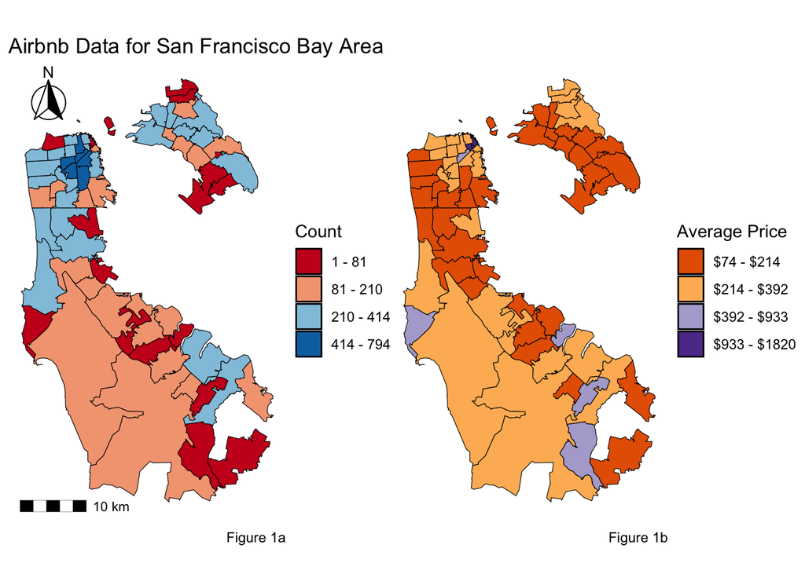

```r
map1 <- map_BA_count + map_BA_meanPrice
map1
```

Figure 1 shows San Francisco’s centre has the highest listings (figure 1a), but not necessarily the highest prices (figure 1b), while the north-east coastal zip codes, shows the highest prices. Oakland has some high counts, but generally has the lowest prices.

The inside Airbnb data provides insights into the dynamics of the short-term market and its impact on various aspects of urban environments, as this data makes use of three “new” types of data sources, i.e., open data, businesses moving online, and citizens as sensors (Arribas-Bel 2014).  
This new form of open data allows for the insight into temporal patterns, spatial distribution, providing insights, and lengths of stay into the changing dynamics of short-term rentals in response to external factors e.g., the COVID-19 pandemic (Li, Han, and Wu 2023). However, biases may arise from voluntary user reviews and selective reporting, influencing the representation of customer experiences and property reputations (Zervas, Proserpio, and Byers 2020).  
Opportunities include conducting spatial regression and quantitative analysis to understand spatio-temporal variations and contextual factors (Crisci et al. 2022).  
Alsudais (2021) has explored the limitations of the dataset. Data is scraped from the Airbnb website using non-updated python scripts which also assumes that Airbnb does not put preventive measures in place or spam data to stop certain data being extracted, leading to false information. Further, data is extracted by listings ID, not if it is an experience or property listings, therefore, reviews of both can be wrongly combined by code due to the same ID, leading to inaccuracies in prices, and reviews.

### 1.4.2 Socio-economic variables

Socio-economic variables, in this case, per capita income (PCI), and population data, are obtained from the US Census Bureau from 2020.

```r
# per capita income
US_zips_income <- get_acs(
  geography = "zip code tabulation area",
  variables = "B19301_001",
  geometry = TRUE,
  year = 2020
)

# population data
US_zips_population <- get_acs(
  geography = "zip code tabulation area",
  variables = "B01003_001E",
  geometry = TRUE,
  year = 2020
)

US_zips_income <- st_transform(US_zips_income, 7131)
US_zips_population <- st_transform(US_zips_population, 7131)

US_zips_income <- dplyr::select(US_zips_income, -c(NAME, variable, moe))
US_zips_income <- dplyr::rename(US_zips_income, per_capita_income = estimate)

US_zips_population <- dplyr::select(US_zips_population, -c(NAME, variable, moe))
US_zips_population <- dplyr::rename(US_zips_population, population = estimate)

bay_zips <- st_intersection(zipCodes, bay_nb)
bay_zips <- dplyr::select(bay_zips, c(ZIP, geometry))

bay_income_zctas <- st_intersection(US_zips_income, bay_zips)
bay_population_zctas <- st_intersection(US_zips_population, bay_zips)

bay_income_zctas <- bay_income_zctas %>%
  filter(!is.na(per_capita_income))
bay_population_zctas <- bay_population_zctas %>%
  filter(!is.na(population))

bay_income_zctas_agg <- bay_income_zctas %>%
  group_by(ZIP) %>%
  dplyr::summarise(
    mean_pci = mean(per_capita_income)
  )

bay_population_zctas_agg <- bay_population_zctas %>%
  group_by(ZIP) %>%
  dplyr::summarise(
    mean_pop = mean(population)
  )
```

```r
# Remove the geometry column from bay_population_zctas_agg
bay_population_zctas_agg_noGeom <- st_drop_geometry(bay_population_zctas_agg)

bay_all <- merge(bay_income_zctas_agg, bay_population_zctas_agg_noGeom, by = "ZIP")
```

As before, Fisher-Jenks is used for this map, allowing for the better interpretation and classification of unevenly distributed data.

```r
bay_all <- bay_all %>%
  mutate(mean_pci = round(mean_pci / 1000))
# Find fisher breaks for data segmentation into 5 groups.
fish_breaks_pci <- classIntervals(bay_all$mean_pci, n = 4, style = "fisher")

# Assign the class breaks to the data
bay_all$fish_breaks_pci <- cut(bay_all$mean_pci, fish_breaks_pci$brks)

bay_all$fish_breaks_pci[is.na(bay_all$fish_breaks_pci)] <- "(3,21.5]"

num_bins <- 4
# Define a color palette for visualizing data.
colour_pci <- brewer.pal(num_bins, "Blues")

income_group = c("$25 - $45.5", "$45.5 - $71", "$71 - $97", "$97 - $135")

plot_pci <- bay_all %>%
  ggplot() +
  geom_sf(aes(fill = fish_breaks_pci), colour = "black") +
  scale_fill_manual(
    values = colour_pci,
    name = "GDP per capita\n(in 1000s)",
    labels = income_group) +
  labs(caption = "Figure 2b") +
  theme_void()
```

```r
bay_all <- bay_all %>%
  mutate(mean_pop = round(mean_pop / 1000))

# Find fisher breaks for data segmentation into 5 groups.
fish_breaks_pop <- classIntervals(bay_all$mean_pop, n = 4, style = "fisher")

# Assign the class breaks to the data
bay_all$fish_breaks_pop <- cut(bay_all$mean_pop, fish_breaks_pop$brks)

bay_all$fish_breaks_pop[is.na(bay_all$fish_breaks_pop)] <- "(25,45.5]"

pop_group = c("3 - 21.5", "21.5 - 32.5", "32.5 - 44", "44 - 57")

colour_pop <- brewer.pal(num_bins, "Reds")

plot_pop <- bay_all %>%
  ggplot() +
  geom_sf(aes(fill = fish_breaks_pop), colour = "black") +
  scale_fill_manual(
    values = colour_pop,
    name = "Population\n(in 1000s)",
    labels = pop_group) +
  labs(title = "Socio-economic data for San Francisco Bay Area", caption = "Figure 2a") +
  annotation_scale(location = "bl", line_width = 0.2, height = unit(0.1, "in"))+
  annotation_north_arrow(location = "tl", style = north_arrow_fancy_orienteering, width = unit(1.25, "cm"), height = unit(1.25, "cm")) +
  theme_void()
```

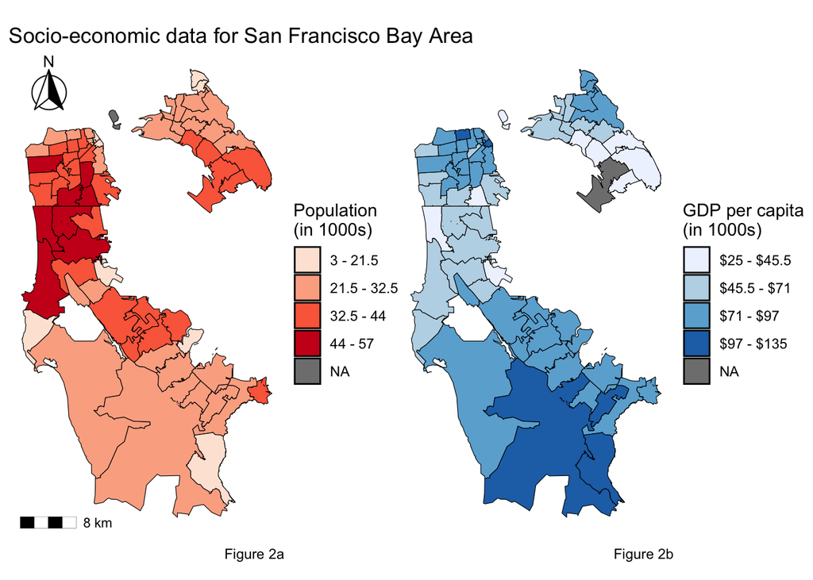

```r
# Combine the two plots using the `+` operator
combined_plot <- plot_pop + plot_pci

# Print the final combined plot
print(combined_plot)
```

Figure 2 shows the spatial distribution of population (2a) and per capita income (2b). Highest populations are around San Francisco, and north San Mateo, with population decreasing moving away from the big cities. Highest GDP is seen in less populated areas notably in the south of San Mateo.  
Predicting Airbnb clusters, it’s expected that high clusters will be in higher-density, higher-income regions like San Francisco and North Mateo. This is because these areas are the most desirable to tourists and business travellers, as there would be a high concentration of attractions, amenities, and activities in such areas (Rodríguez and Moraes 2021a). Additionally, these areas have the most infrastructure, i.e., public transport, to support tourists (Rodríguez and Moraes 2021b).

### 1.4.3 Combining Data Sets

```r
airbnb_seVariables <- st_join(bay_all, airbnb_zip_agg_filtered)

airbnb_seVariables <- dplyr::select(airbnb_seVariables, -c(ZIP.y))
airbnb_seVariables <- dplyr::rename(airbnb_seVariables, ZIP = ZIP.x)

airbnb_seVariables$log_mean_price <- log(airbnb_seVariables$mean_price)

biClasses <- bi_class(airbnb_seVariables, x = mean_pci, y = log_mean_price, style = "quantile", dim = 3)
```

[figure not shown]

```r
bi_Map <- ggplot()+
  geom_sf(data = biClasses, mapping = aes(fill = bi_class), color = "black", size = 0.1, show.legend = FALSE) +
  labs(title = "Per Capita Income and Airbnb Listing Prices", caption = "Figure 3") +
  bi_scale_fill(pal = "DkViolet", dim = 3) +
  coord_sf(crs = st_crs(7131), datum = NA) +
  theme(plot.margin = unit(c(0.5,0.5,0.5,0.5), "cm"),
        plot.title = element_text(size = 18, face = "bold", hjust = 0.5)) +
  annotation_scale(location = "bl", line_width = 0.2, height = unit(0.05, "in")) +
  annotation_north_arrow(location = "tl", which_north = "true",
                         height = unit(1.25, "cm"), width = unit(1.25, "cm"),
                         style = north_arrow_fancy_orienteering) +
  theme_minimal()

bi_Legend <- bi_legend(pal = "DkViolet", dim = 3, xlab = "Higher PCI", ylab = "Higher price", size = 7)

plot <- ggdraw() +
  draw_plot(bi_Map, 0, 0, 1, 1) +
  draw_plot(bi_Legend, 0.55, 0.358, 0.28, 0.28)

plot
```

```r
res <- cor.test(airbnb_seVariables$mean_pci, airbnb_seVariables$mean_price,
                    method = "pearson")

res$p.value
res$estimate
```

Table 1: Pearson correlation result

| P Value | Estimate |
| --- | --- |
| 0.00 | 0.33 |

Figure 3 shows the areas that see higher PCI see higher average listing prices, supported by the correlation test result of 0.33 (table 1) indicating a positive correlation between the variables.

As in the hypothesis, areas that have high PCI experience higher listings prices, especially seen in the centre of San Francisco. Notably, Oakland, especially the inner city, shows low per capita and low listing prices.  
The rise of short-term rentals, like Airbnb, may fuel gentrification in specific areas, potentially elevating property values and rental prices. This phenomenon, reflected in higher listing prices, is often associated with increased PCI in those locations (Wachsmuth and Weisler 2018).

### 1.4.4 Spatial Autocorrelation of GDP

To compute spatial autocorrelation of PCI, the queen contiguity spatial weights encompassing all neighbouring areas that share a border or vertex with a focal area (Zahnd, Bell, and Larson 2021). This method provides a thorough evaluation of spatial relationships. Additionally, the Local Moran’s I is employed to reveal spatial clusters of similar values. This approach is valuable for identifying localized patterns in PCI distribution.

```r
bay_all_spaitalWeights <- bay_all

nb_q <- poly2nb(bay_all_spaitalWeights, queen = TRUE) # Construct neighbours list from polygon list

w_queen <- nb2listw(nb_q, style = "B", zero.policy=TRUE) # Create a spatial weights matrix using queen contiguity

isolates <- which(w_queen$neighbours == "0")

bay_all_spaitalWeights <- bay_all_spaitalWeights[-c(isolates),]

nb_q <- poly2nb(bay_all_spaitalWeights, queen = TRUE)
w_queen_std <- nb2listw(nb_q, style = "W")
```

```r
bay_all_spaitalWeights$w_pci <- lag.listw(w_queen_std, bay_all_spaitalWeights$mean_pci)

bay_all_spaitalWeights$pci_std <- (bay_all_spaitalWeights$mean_pci - mean(bay_all_spaitalWeights$mean_pci))/sd(bay_all_spaitalWeights$mean_pci)

bay_all_spaitalWeights$w_pci_std <- lag.listw(w_queen_std, bay_all_spaitalWeights$pci_std)
```

```r
lisa_perm <- localmoran_perm(bay_all_spaitalWeights$mean_pci, w_queen_std, nsim=1000, alternative = "two.sided")
```

```r
quadrants <- hotspot(lisa_perm, Prname="Pr(z != E(Ii)) Sim", cutoff=0.1)
```

```r
bay_all_spaitalWeights$quadrant <- as.character(quadrants)  %>% replace_na("Not significant")

bay_all_spaitalWeights <- st_make_valid(bay_all_spaitalWeights)
```

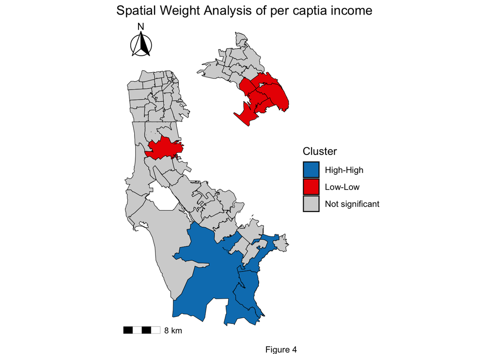

```r
cluster_colors <- c("High-High" = "#047fbd",
                    "Low-Low" = "#ea0000",
                    "Not significant" = "#d3d3d3")

ggplot(data = bay_all_spaitalWeights) +
  geom_sf(aes(fill = quadrant), color = "black") +
  labs(title = "Spatial Weight Analysis of per captia income", caption = "Figure 4") +
  scale_fill_manual(values = cluster_colors, name = "Cluster") +
  annotation_scale(location = "bl", line_width = 0.2, height = unit(0.1, "in"))+
  annotation_north_arrow(location = "tl", style = north_arrow_fancy_orienteering, width = unit(1.25, "cm"), height = unit(1.25, "cm")) +
  theme_void()
```

Figure 4 displays a spatial weights matrix for PCI. The only high-high cluster is observed in the south of San Mateo, with a large low cluster in Oakland. San Francisco exhibits high variability in income levels, which is supported by Fisher et al. (2022).

## Part 2

### Data Preparation

```r
# Obtain the San Fransisco zip code areas
o_nb <- st_set_geometry(o_nb, "geometry")
zipCodes <- st_set_geometry(zipCodes, "geometry")

o_zipCodes <- bay_all[o_nb,]
```

```r
# Grant internet connection
library(curl)
curl::has_internet()
assign("has_internet_via_proxy", TRUE, environment(curl::has_internet))
```

```r
osm_q_o <- opq("Oakland") %>%
    add_osm_feature(key = "amenity", value = "restaurant") %>%
  osmdata_sf () # transforming to sf object
```

```r
point_resturants <- osm_q_o$osm_points %>%
  filter(amenity == "restaurant") %>%
  st_transform(7131)

centroid_resturants <- osm_q_o$osm_polygons %>%
  st_centroid() %>%
  st_transform(7131)

all_restaurants <- bind_rows(centroid_resturants, point_resturants)

all_restaurants <- st_transform(all_restaurants, crs = 7131)
```

```r
o_restaurants <- st_intersection(all_restaurants, o_zipCodes)
```

```r
o_listings_zips <- st_intersection(airbnb_zip_agg_filtered, o_zipCodes)
```

```r
vars <- c("osm_id", "geometry")
o_restaurants_sub <- dplyr::select(o_restaurants,vars)

o_restaurants_geom <- sf::st_as_sf(
  o_restaurants_sub,
  coords = c("osm_id"),
  crs = 7131
)

o_rest_ZIP <- st_join(o_zipCodes, o_restaurants_geom)

o_rest_ZIP_agg <- o_rest_ZIP %>%
  group_by(ZIP) %>%
  dplyr::summarise(
    count_rest = ifelse(all(is.na(osm_id)), 0, sum(!is.na(osm_id)))
  )

o_rest_airbnb <- st_join(o_rest_ZIP_agg, o_listings_zips, by = "ZIP")

o_rest_airbnb <- dplyr::select(o_rest_airbnb, ZIP.x, count_rest, geometry, count_airbnb)
o_rest_airbnb <- dplyr::rename(o_rest_airbnb, ZIP = ZIP.x)
```

### DBSCAN

```r
vars <- c("osm_id", "geometry")
d.sub <- dplyr::select(o_restaurants,vars)
```

```r
# Convert geometries to longitude and latitude
d.sub_longlat <- d.sub %>% extract(geometry, c('lat', 'lon'), '\\((.*), (.*)\\)', convert = TRUE)

locs = dplyr::select(d.sub_longlat, lat, lon)

#scalling the data points
locs.scaled = scale(locs,center = T,scale = T)

dbscan::kNNdistplot(locs.scaled,k=1)
abline(h=0.15,lty = 2,col=rainbow(1),main="eps optimal value")
```

[output not shown]

```r
# eps optimal value = 0.15
```

Setting MinPts = 10 prioritizes significant local density within clusters. This choice aids in noise reduction, filtering out less dense regions and promotes the formation of larger, consolidated clusters, enhancing the identification of major activity centres (Lin, Kuo, and Chuang 2020).

```r
set.seed(123456789)
db <- dbscan::dbscan(locs.scaled, eps = 0.15, minPts = 10)

o_restaurants_geom$cluster <- db$cluster
```

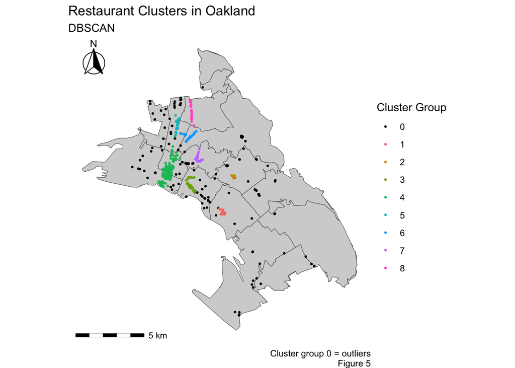

```r
# Example color assignment for clusters
cluster_colors <- c("#000000", "#F8766D", "#CE9600", "#7CAE00", "#09BE66", "#00BFC4", "#00A9FF", "#C77BFF", "#FF62CC")

ggplot()+
  geom_sf(data = o_zipCodes, fill = "lightgrey", size = 1.5) +
  geom_sf(data = o_restaurants_geom, aes(color = factor(cluster)), size = 0.5) +
  scale_color_manual(values = cluster_colors, name = "Cluster Group") +
  theme(legend.position = "right") +
  labs(title = "Restaurant Clusters in Oakland", subtitle = "DBSCAN", caption = "Cluster group 0 = outliers\nFigure 5") +
  annotation_scale(location = "bl", line_width = 0.2, height = unit(0.05, "in")) +
  annotation_north_arrow(location = "tl", which_north = "true",
                         height = unit(1.25, "cm"), width = unit(1.25, "cm"),
                         style = north_arrow_fancy_orienteering) +
  theme_void()
```

This analysis can assist potential restaurant owners in Oakland. Considering the substantial use of restaurants by Airbnb tourists (Tussyadiah and Pesonen 2016), identifying areas with a high number of Airbnbs (figure 1a) and minimal restaurant competition is crucial (figure 5). The southeast zip code area stands out based on these factors, with a high Airbnb presence and a lack of restaurant clusters.

# Conclusion

In conclusion, this analysis reveals insights into the San Francisco Bay Area’s urban dynamics, drawing from Inside Airbnb data and socio-economic variables. Notably, high per capita income areas correlate with elevated Airbnb listing prices, reflecting the influence of socio-economic factors on short-term rental dynamics. The study identifies potential hotspots for new restaurants, such as the southeast of Oakland, based on Airbnb presence and limited competition. Despite data limitations, these findings offer practical implications for businesses and stakeholders, underscoring the complex interplay between short-term rentals, urban socio-economics, and spatial patterns.

## References

Alsudais, Abdulkareem. 2021. ‘Incorrect Data in the Widely Used Inside Airbnb Dataset’. *Decision Support Systems* 141 (February): 113453. https://doi.org/10.1016/j.dss.2020.113453.

Arribas-Bel, Daniel. 2014. ‘Accidental, Open and Everywhere: Emerging Data Sources for the Understanding of Cities’. *Applied Geography* 49 (May): 45–53. https://doi.org/10.1016/j.apgeog.2013.09.012.

Crisci, Massimiliano, Federico Benassi, Hamidreza Rabiei-Dastjerdi, and Gavin McArdle. 2022. ‘Spatio-Temporal Variations and Contextual Factors of the Supply of Airbnb in Rome. An Initial Investigation’. *Letters in Spatial and Resource Sciences* 15 (2): 237–53. https://doi.org/10.1007/s12076-022-00302-y.

Cromley, Robert G, and Ellen K Cromley. 2009. ‘Choropleth Map Legend Design for Visualizing Community Health Disparities’. *International Journal of Health Geographics* 8 (1): 52. https://doi.org/10.1186/1476-072x-8-52.

Fisher, Stephanie A., Allie Sakowicz, Cynthia Barnard, Seth Kidder, and Emily S. Miller. 2022. ‘Neighborhood Deprivation and Preterm Delivery During the Coronavirus 2019 Pandemic’. *American Journal of Obstetrics & Gynecology MFM* 4 (1): 100493. https://doi.org/10.1016/j.ajogmf.2021.100493.

Golebiowska, Izabela. 2019. ‘Evaluating Rainbow Colour Scheme in Social Data Mapping’. *Abstracts of the ICA* 1 (July): 1–2. https://doi.org/10.5194/ica-abs-1-96-2019.

Lee, Gyoung-Ju, Son-Il Pak, Kwang-Nyeong Lee, and Sungjo Hong. 2019. ‘Movement-Based Biosecurity Zones for Control of Highly Infectious Animal Diseases: Application of Community Detection Analysis to a Livestock Vehicle Movement Network’. *Sustainability* 11 (6): 1642. https://doi.org/10.3390/su11061642.

Li, Peize, Sun Sheng Han, and Hao Wu. 2023. ‘“Home Away from Home” in Pandemic Times: How Has COVID-19 Changed the Airbnb Market in Melbourne?’ *International Journal of Housing Markets and Analysis* 16 (3): 450–73. https://doi.org/10.1108/ijhma-08-2022-0123.

Lin, Jun-Lin, Jen-Chieh Kuo, and Hsing-Wang Chuang. 2020. ‘Improving Density Peak Clustering by Automatic Peak Selection and Single Linkage Clustering’. *Symmetry* 12 (7): 1168. https://doi.org/10.3390/sym12071168.

Morales-Alemán, Mercedes M., Qinglin Hu, Gwendolyn Ferreti, and Lea G. Yerby. 2022. ‘Geographic Access to Primary Healthcare Services Among Latinos/as/x in Western Alabama’. *Southern Medical Journal* 115 (12): 864–69. https://doi.org/10.14423/smj.0000000000001476.

Olson, Judy M., and Cynthia A. Brewer. 1997. ‘An Evaluation of Color Selections to Accommodate Map Users with Color-Vision Impairments’. *Annals of the Association of American Geographers* 87 (1): 103–34. https://doi.org/10.1111/0004-5608.00043.

Rodríguez, Diana E. Forero, and Milena Lima de Moraes. 2021a. ‘Spatial Influence on Qualitative Food Consumption in Colombia’. *Ciência & Saúde Coletiva* 26 (12): 6165–74. https://doi.org/10.1590/1413-812320212612.25702020.

———. 2021b. ‘Spatial Influence on Qualitative Food Consumption in Colombia’. *Ciência & Saúde Coletiva* 26 (12): 6165–74. https://doi.org/10.1590/1413-812320212612.25702020.

Tussyadiah, Iis P., and Juho Pesonen. 2016. ‘Impacts of Peer-to-Peer Accommodation Use on Travel Patterns’. *Journal of Travel Research* 55 (8): 1022–40. https://doi.org/10.1177/0047287515608505.

Wachsmuth, David, and Alexander Weisler. 2018. ‘Airbnb and the Rent Gap: Gentrification Through the Sharing Economy’. *Environment and Planning A: Economy and Space* 50 (6): 1147–70. https://doi.org/10.1177/0308518x18778038.

Yildirim, Faruk, and Ahmet Kaya. 2008. ‘Selecting Map Projections in Minimizing Area Distortions in GIS Applications’. *Sensors* 8 (12): 7809–17. https://doi.org/10.3390/s8127809.

Zahnd, Whitney E., Nathaniel Bell, and Annie E. Larson. 2021. ‘Geographic, Racial/Ethnic, and Socioeconomic Inequities in Broadband Access’. *The Journal of Rural Health* 38 (3): 519–26. https://doi.org/10.1111/jrh.12635.

Zervas, Georgios, Davide Proserpio, and John W. Byers. 2020. ‘A First Look at Online Reputation on Airbnb, Where Every Stay Is Above Average’. *Marketing Letters* 32 (1): 1–16. https://doi.org/10.1007/s11002-020-09546-4.